# Random Forest for multiclass classification

Filippo Biscarini

7/9/2020

## Random Forest for multiclass classification (tidymodels inside)

We now move on from binary to multiclass classification, and put together also the use of `tidymodels`. We use the same dataset on diabetes and metabolomics that we used for the Lasso model using `tidymodels`

```r
library("vip")
```

```r
library("ggplot2")
library("tidyverse")
library("tidymodels")
library("data.table")
library("randomForest")
mtbsl1 <- fread("../data/MTBSL1.tsv")
names(mtbsl1)[c(4:ncol(mtbsl1))] <- paste("mtbl",seq(1,ncol(mtbsl1)-3), sep = "_")
```

We combine the variables `Gender` and `Metabolic_syndrom` to create a synthetic outcome variable with four classes:

```r
mtbsl1$gender_status <- paste(mtbsl1$Gender,mtbsl1$Metabolic_syndrome,sep="_")
mtbsl1 %>% group_by(gender_status) %>%
    summarise(N=n())
```

```
## # A tibble: 4 x 2
##   gender_status                N
##   <chr>                    <int>
## 1 Female_Control Group        28
## 2 Female_diabetes mellitus    26
## 3 Male_Control Group          56
## 4 Male_diabetes mellitus      22
```

#### Data splitting

We first split the data in the training and test sets (stratifying by the categorical outcome):

```r
diab_dt <- select(mtbsl1, -c(`Primary ID`, Gender, Metabolic_syndrome))
mtbsl1_split <- initial_split(diab_dt, strata = gender_status, prop = 0.75)
mtbsl1_train <- training(mtbsl1_split)
mtbsl1_test <- testing(mtbsl1_split)

nrow(mtbsl1_train)
```

```
## [1] 100
```

```r
nrow(mtbsl1_test)
```

```
## [1] 32
```

#### Preprocessing

We use tidymodels to build a recipe for data preprocessing:

- remove correlated variables
- remove non informative variables (zero variance)
- standardize all variables
- impute missing data (Random Forest does not handle missing data)

```r
diab_recipe <- mtbsl1_train %>%
  recipe(gender_status ~ .) %>%
  step_corr(all_predictors(), threshold = 0.9) %>%
  step_zv(all_numeric(), -all_outcomes()) %>%
  step_normalize(all_numeric(), -all_outcomes()) %>%
  step_knnimpute(all_numeric(), neighbors = 5)
```

```r
prep_diab <- prep(diab_recipe)
print(prep_diab)
```

```
## Data Recipe
##
## Inputs:
##
##       role #variables
##    outcome          1
##  predictor        188
##
## Training data contained 100 data points and no missing data.
##
## Operations:
##
## Correlation filter removed mtbl_12, mtbl_36, mtbl_65, ... [trained]
## Zero variance filter removed no terms [trained]
## Centering and scaling for mtbl_1, mtbl_2, mtbl_3, mtbl_4, mtbl_5, ... [trained]
## K-nearest neighbor imputation for mtbl_2, mtbl_3, mtbl_4, mtbl_5, mtbl_6, ... [trained]
```

```r
training_set <- juice(prep_diab)
head(training_set)
```

```
## # A tibble: 6 x 158
##   mtbl_1 mtbl_2 mtbl_3 mtbl_4 mtbl_5 mtbl_6  mtbl_7 mtbl_8 mtbl_9 mtbl_10
##    <dbl>  <dbl>  <dbl>  <dbl>  <dbl>  <dbl>   <dbl>  <dbl>  <dbl>   <dbl>
## 1  0.182 -0.101  0.141 -0.342 -0.337 -0.431 -0.554  -0.496 -0.142  -0.450
## 2 -0.494 -0.573 -0.276 -0.342 -0.337 -0.431  0.0204  1.81   0.181  -0.450
## 3 -0.775 -0.573 -0.675 -0.342 -0.337 -0.431 -0.554   1.41  -0.705  -0.450
## 4  0.514  0.194  0.851  1.62   1.44   0.710  1.75    3.03   1.97    1.20
## 5 -0.715 -0.573 -0.675 -0.342 -0.337 -0.431 -0.554   1.32  -0.705  -0.450
## 6  5.16   6.12   5.66   7.81   4.59   7.42   4.11    2.84   4.81    5.71
## # … with 148 more variables: mtbl_11 <dbl>, mtbl_13 <dbl>, mtbl_14 <dbl>,
## #   mtbl_15 <dbl>, mtbl_16 <dbl>, mtbl_17 <dbl>, mtbl_18 <dbl>, mtbl_20 <dbl>,
## #   mtbl_21 <dbl>, mtbl_22 <dbl>, mtbl_23 <dbl>, mtbl_24 <dbl>, mtbl_25 <dbl>,
## #   mtbl_26 <dbl>, mtbl_28 <dbl>, mtbl_29 <dbl>, mtbl_30 <dbl>, mtbl_31 <dbl>,
## #   mtbl_32 <dbl>, mtbl_33 <dbl>, mtbl_34 <dbl>, mtbl_35 <dbl>, mtbl_37 <dbl>,
## #   mtbl_38 <dbl>, mtbl_40 <dbl>, mtbl_41 <dbl>, mtbl_42 <dbl>, mtbl_43 <dbl>,
## #   mtbl_44 <dbl>, mtbl_45 <dbl>, mtbl_46 <dbl>, mtbl_47 <dbl>, mtbl_48 <dbl>,
## #   mtbl_49 <dbl>, mtbl_50 <dbl>, mtbl_51 <dbl>, mtbl_52 <dbl>, mtbl_54 <dbl>,
## #   mtbl_55 <dbl>, mtbl_56 <dbl>, mtbl_57 <dbl>, mtbl_58 <dbl>, mtbl_59 <dbl>,
## #   mtbl_60 <dbl>, mtbl_61 <dbl>, mtbl_62 <dbl>, mtbl_63 <dbl>, mtbl_64 <dbl>,
## #   mtbl_68 <dbl>, mtbl_69 <dbl>, mtbl_70 <dbl>, mtbl_71 <dbl>, mtbl_72 <dbl>,
## #   mtbl_73 <dbl>, mtbl_74 <dbl>, mtbl_75 <dbl>, mtbl_76 <dbl>, mtbl_77 <dbl>,
## #   mtbl_78 <dbl>, mtbl_79 <dbl>, mtbl_81 <dbl>, mtbl_82 <dbl>, mtbl_83 <dbl>,
## #   mtbl_84 <dbl>, mtbl_85 <dbl>, mtbl_86 <dbl>, mtbl_87 <dbl>, mtbl_88 <dbl>,
## #   mtbl_89 <dbl>, mtbl_90 <dbl>, mtbl_91 <dbl>, mtbl_92 <dbl>, mtbl_94 <dbl>,
## #   mtbl_98 <dbl>, mtbl_101 <dbl>, mtbl_102 <dbl>, mtbl_103 <dbl>,
## #   mtbl_104 <dbl>, mtbl_106 <dbl>, mtbl_107 <dbl>, mtbl_108 <dbl>,
## #   mtbl_115 <dbl>, mtbl_116 <dbl>, mtbl_119 <dbl>, mtbl_120 <dbl>,
## #   mtbl_121 <dbl>, mtbl_122 <dbl>, mtbl_123 <dbl>, mtbl_124 <dbl>,
## #   mtbl_125 <dbl>, mtbl_126 <dbl>, mtbl_127 <dbl>, mtbl_128 <dbl>,
## #   mtbl_129 <dbl>, mtbl_130 <dbl>, mtbl_131 <dbl>, mtbl_132 <dbl>,
## #   mtbl_133 <dbl>, mtbl_134 <dbl>, mtbl_135 <dbl>, …
```

#### Model building

We now specify the structure of our model:

- hyperparameters to tune: `mtry` (number of features to sample for each tree) and `min_n` (minimum number of data points in a node to allow further splitting)
- number of trees in the forest
- the problem at hand (classification)
- the engine (R package)

Then we put this in a workflow together with the preprocessing recipe

```r
tune_spec <- rand_forest(
  mtry = tune(),
  trees = 100,
  min_n = tune()
) %>%
  set_mode("classification") %>%
  set_engine("randomForest")
```

```r
tune_wf <- workflow() %>%
  add_formula(gender_status ~ .) %>%
  add_model(tune_spec)
```

#### Tuning the hyperparameters

We use k-fold cross-validation to tune the hyperparameters in the training set

```r
trees_folds <- vfold_cv(training_set, v = 5, repeats = 5)
```

```r
print(trees_folds)
```

```
## #  5-fold cross-validation repeated 5 times
## # A tibble: 25 x 3
##    splits          id      id2
##    <list>          <chr>   <chr>
##  1 <split [80/20]> Repeat1 Fold1
##  2 <split [80/20]> Repeat1 Fold2
##  3 <split [80/20]> Repeat1 Fold3
##  4 <split [80/20]> Repeat1 Fold4
##  5 <split [80/20]> Repeat1 Fold5
##  6 <split [80/20]> Repeat2 Fold1
##  7 <split [80/20]> Repeat2 Fold2
##  8 <split [80/20]> Repeat2 Fold3
##  9 <split [80/20]> Repeat2 Fold4
## 10 <split [80/20]> Repeat2 Fold5
## # … with 15 more rows
```

```r
doParallel::registerDoParallel()

tune_res <- tune_grid(
  tune_wf,
  resamples = trees_folds,
  grid = 20
)
```

```
## i Creating pre-processing data to finalize unknown parameter: mtry
```

```r
print(tune_res)
```

```
## # Tuning results
## # 5-fold cross-validation repeated 5 times
## # A tibble: 25 x 5
##    splits          id      id2   .metrics          .notes
##    <list>          <chr>   <chr> <list>            <list>
##  1 <split [80/20]> Repeat1 Fold1 <tibble [40 × 6]> <tibble [0 × 1]>
##  2 <split [80/20]> Repeat1 Fold2 <tibble [40 × 6]> <tibble [0 × 1]>
##  3 <split [80/20]> Repeat1 Fold3 <tibble [40 × 6]> <tibble [0 × 1]>
##  4 <split [80/20]> Repeat1 Fold4 <tibble [40 × 6]> <tibble [0 × 1]>
##  5 <split [80/20]> Repeat1 Fold5 <tibble [40 × 6]> <tibble [0 × 1]>
##  6 <split [80/20]> Repeat2 Fold1 <tibble [40 × 6]> <tibble [0 × 1]>
##  7 <split [80/20]> Repeat2 Fold2 <tibble [40 × 6]> <tibble [0 × 1]>
##  8 <split [80/20]> Repeat2 Fold3 <tibble [40 × 6]> <tibble [0 × 1]>
##  9 <split [80/20]> Repeat2 Fold4 <tibble [40 × 6]> <tibble [0 × 1]>
## 10 <split [80/20]> Repeat2 Fold5 <tibble [40 × 6]> <tibble [0 × 1]>
## # … with 15 more rows
```

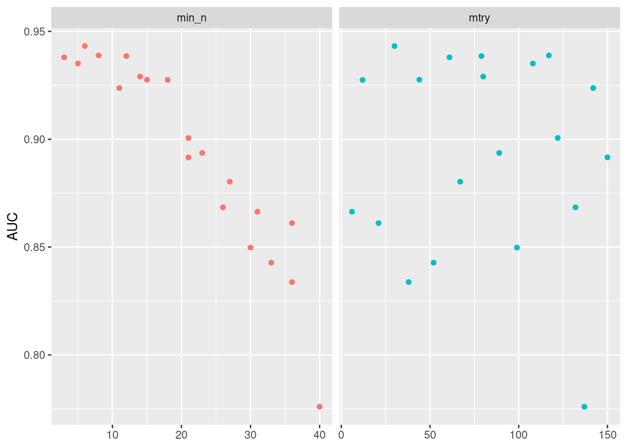

```r
library("repr")
options(repr.plot.width=14, repr.plot.height=8)

tune_res %>%
  collect_metrics() %>%
  filter(.metric == "roc_auc") %>%
  select(mean, min_n, mtry) %>%
  pivot_longer(min_n:mtry,
               values_to = "value",
               names_to = "parameter"
  ) %>%
  ggplot(aes(value, mean, color = parameter)) +
  geom_point(show.legend = FALSE) +
  facet_wrap(~parameter, scales = "free_x") +
  labs(x = NULL, y = "AUC")
```

```r
m <- round(sqrt(ncol(training_set)-1),0)
print(m)
```

```
## [1] 13
```

```r
rf_grid <- grid_regular(
  mtry(range = c(m-2, m+2)),
  min_n(range = c(8, 12)),
  levels = 3
)
```

```r
print(rf_grid)
```

```
## # A tibble: 9 x 2
##    mtry min_n
##   <int> <int>
## 1    11     8
## 2    13     8
## 3    15     8
## 4    11    10
## 5    13    10
## 6    15    10
## 7    11    12
## 8    13    12
## 9    15    12
```

```r
regular_res <- tune_grid(
  tune_wf,
  resamples = trees_folds,
  grid = rf_grid
)
```

```r
print(regular_res)
```

```
## # Tuning results
## # 5-fold cross-validation repeated 5 times
## # A tibble: 25 x 5
##    splits          id      id2   .metrics          .notes
##    <list>          <chr>   <chr> <list>            <list>
##  1 <split [80/20]> Repeat1 Fold1 <tibble [18 × 6]> <tibble [0 × 1]>
##  2 <split [80/20]> Repeat1 Fold2 <tibble [18 × 6]> <tibble [0 × 1]>
##  3 <split [80/20]> Repeat1 Fold3 <tibble [18 × 6]> <tibble [0 × 1]>
##  4 <split [80/20]> Repeat1 Fold4 <tibble [18 × 6]> <tibble [0 × 1]>
##  5 <split [80/20]> Repeat1 Fold5 <tibble [18 × 6]> <tibble [0 × 1]>
##  6 <split [80/20]> Repeat2 Fold1 <tibble [18 × 6]> <tibble [0 × 1]>
##  7 <split [80/20]> Repeat2 Fold2 <tibble [18 × 6]> <tibble [0 × 1]>
##  8 <split [80/20]> Repeat2 Fold3 <tibble [18 × 6]> <tibble [0 × 1]>
##  9 <split [80/20]> Repeat2 Fold4 <tibble [18 × 6]> <tibble [0 × 1]>
## 10 <split [80/20]> Repeat2 Fold5 <tibble [18 × 6]> <tibble [0 × 1]>
## # … with 15 more rows
```

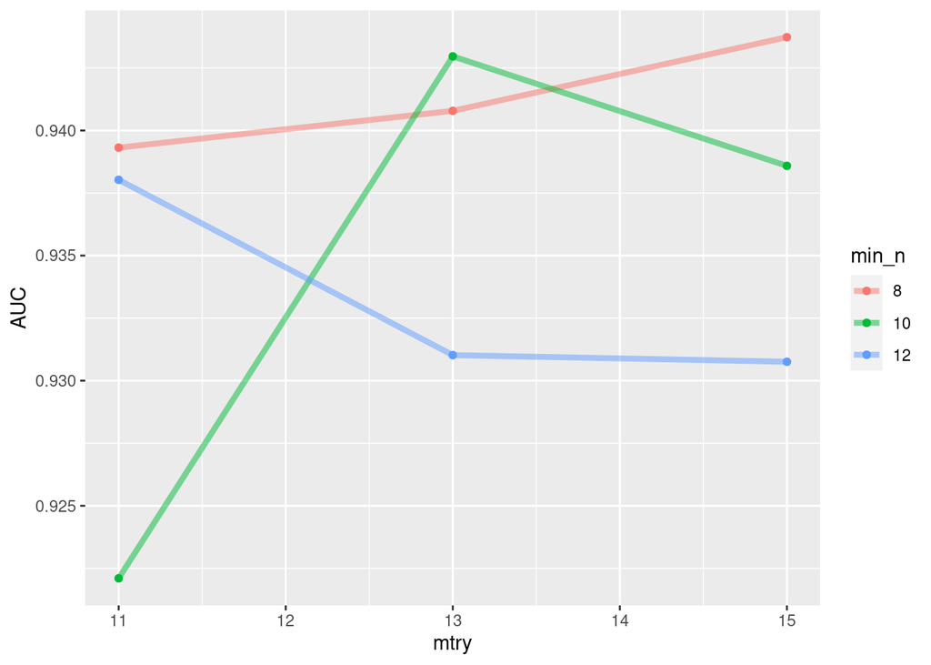

```r
regular_res %>%
  collect_metrics() %>%
  filter(.metric == "roc_auc") %>%
  mutate(min_n = factor(min_n)) %>%
  ggplot(aes(mtry, mean, color = min_n)) +
  geom_line(alpha = 0.5, size = 1.5) +
  geom_point() +
  labs(y = "AUC")
```

#### Final model

We now select the best model from the hyperparameters tuning, and fit it to the training set:

```r
best_auc <- select_best(tune_res, "roc_auc")
print(best_auc)
```

```
## # A tibble: 1 x 3
##    mtry min_n .config
##   <int> <int> <chr>
## 1    30     6 Preprocessor1_Model13
```

```r
final_rf <- finalize_model(
  tune_spec,
  best_auc
)

print(final_rf)
```

```
## Random Forest Model Specification (classification)
##
## Main Arguments:
##   mtry = 30
##   trees = 100
##   min_n = 6
##
## Computational engine: randomForest
```

```r
final_wf <- workflow() %>%
  add_recipe(diab_recipe) %>%
  add_model(final_rf)

final_res <- final_wf %>%
  last_fit(mtbsl1_split)
```

```r
print(final_res)
```

```
## # Resampling results
## # Manual resampling
## # A tibble: 1 x 6
##   splits       id           .metrics      .notes       .predictions    .workflow
##   <list>       <chr>        <list>        <list>       <list>          <list>
## 1 <split [100… train/test … <tibble [2 ×… <tibble [0 … <tibble [32 × … <workflo…
```

```r
final_res %>%
  collect_metrics()
```

```
## # A tibble: 2 x 4
##   .metric  .estimator .estimate .config
##   <chr>    <chr>          <dbl> <chr>
## 1 accuracy multiclass     0.844 Preprocessor1_Model1
## 2 roc_auc  hand_till      0.950 Preprocessor1_Model1
```

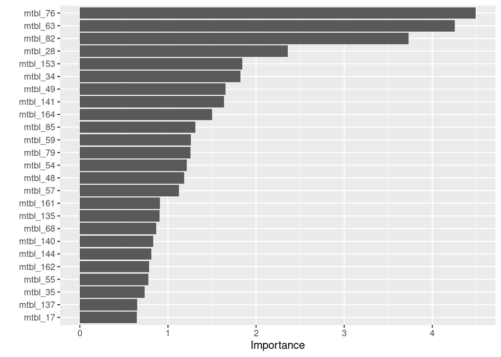

```r
final_res %>%
  pluck(".workflow", 1) %>%
  pull_workflow_fit() %>%
  #vip(num_features = 20, geom = "point")
  vip(num_features = 25)
```

#### Predictions

```r
final_res %>%
  collect_predictions()
```

```
## # A tibble: 32 x 9
##    id    `.pred_Female_C… `.pred_Female_d… `.pred_Male_Con… `.pred_Male_dia…
##    <chr>            <dbl>            <dbl>            <dbl>            <dbl>
##  1 trai…             0.4             0.2               0.08             0.32
##  2 trai…             0.34            0.36              0.08             0.22
##  3 trai…             0.2             0.22              0.23             0.35
##  4 trai…             0.08            0.07              0.68             0.17
##  5 trai…             0.14            0.23              0.07             0.56
##  6 trai…             0.15            0.290             0.2              0.36
##  7 trai…             0.14            0.48              0.13             0.25
##  8 trai…             0.15            0.67              0.05             0.13
##  9 trai…             0.17            0.64              0.04             0.15
## 10 trai…             0.15            0.69              0.08             0.08
## # … with 22 more rows, and 4 more variables: .row <int>, .pred_class <fct>,
## #   gender_status <fct>, .config <chr>
```

```r
cm <- final_res %>%
  collect_predictions() %>%
  conf_mat(gender_status, .pred_class)

print(cm)
```

```
##                           Truth
## Prediction                 Female_Control Group Female_diabetes mellitus
##   Female_Control Group                        5                        0
##   Female_diabetes mellitus                    0                        6
##   Male_Control Group                          2                        0
##   Male_diabetes mellitus                      0                        0
##                           Truth
## Prediction                 Male_Control Group Male_diabetes mellitus
##   Female_Control Group                      0                      1
##   Female_diabetes mellitus                  0                      0
##   Male_Control Group                       13                      1
##   Male_diabetes mellitus                    1                      3
```

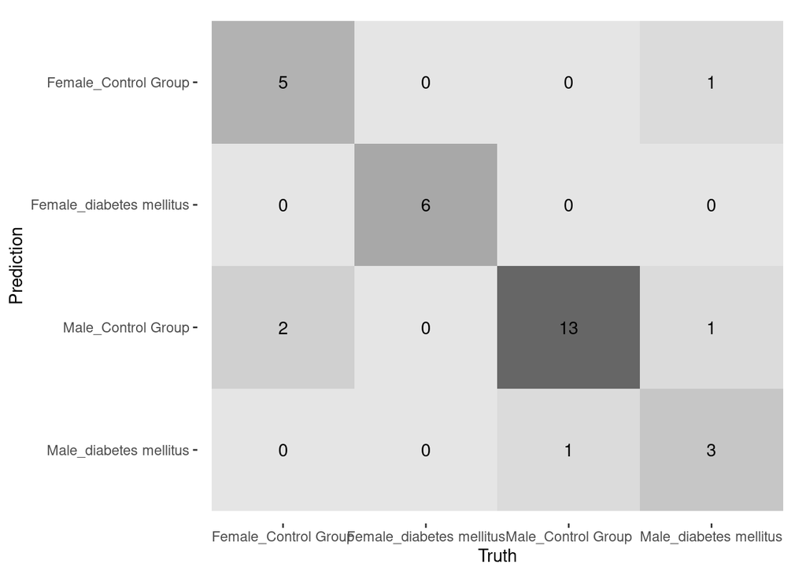

```r
autoplot(cm, type = "heatmap")
```